# ECON 5181 Assignment 2

Due: April 5, 2024, noon. Submission on Blackboard.

DON'T forget your VeriGuide report and honesty declaration!

*The copyright of this content, produced by staff members/ teachers of The Chinese University of Hong Kong (CUHK), belongs to CUHK. Students shall not distribute, share, copy or upload the content to a third party.*

## Q1. Regression trees

We consider the following data generating process:

$$Y_i = X_{i1} + X_{i2} + U_i$$

where $X_1, X_2$ are independent standard normal random variables, and $U$ is standard normal, independent of the $X$'s.

In this exercise, we study the behavior of regression trees in this additive model.

#### 1. Simulate $S = 500$ samples according to the DGP, each with a sample size $n = 1600$. In each simulated sample, randomly split the data into 1200 observations that will form a training set and 400 observations that will form the test set.

```python
import pandas as pd
import numpy as np
import matplotlib.pyplot as plt
import sklearn as sk
import random
```

```python
def sythetic_data(S):
    '''
    S: number of simulations
    return: a list of dataframes, each dataframe is a simulation which contains 4 columns: x1, x2, u, y
    '''
    data = []
    data_w = []
    for i in range(S):
        x1 = np.random.normal(0, 1, 1600)
        x2 = np.random.normal(0, 1, 1600)
        u = np.random.normal(0, 1, 1600)
        w = x1 + x2
        y = x1 + x2 + u
        df = pd.DataFrame({'x1': x1, 'x2': x2, 'y': y})
        df_w = pd.DataFrame({'w': w, 'y': y})
        data.append(df)
        data_w.append(df_w)
    return data, data_w
data, data_w = sythetic_data(500)
data, data_w = np.array(data), np.array(data_w)
train_X, train_Y, test_X, test_Y = data[:, :1200, :2], data[:, :1200, 2:], data[:, 1200:, :2], data[:, 1200:, 2:]
train_X.shape, train_Y.shape, test_X.shape, test_Y.shape
```

```
((500, 1200, 2), (500, 1200, 1), (500, 400, 2), (500, 400, 1))
```

#### 2. Estimate a regression tree of $Y_i$ on $X_{i1}, X_{i2}$ in each simulated sample.

You will use R pacakge to implement CART, which does pruning and cross validation

```python
# run a CART regression tree with cross-validation
from sklearn.tree import DecisionTreeRegressor
from sklearn.model_selection import cross_val_score
from sklearn.metrics import mean_squared_error
from sklearn import tree

def main(*dat):
    train_X, train_Y, test_X, test_Y = dat[0], dat[1], dat[2], dat[3]
    simulation_scores = np.empty(0)
    num_leaves = np.empty(0)
    for i in range(500):
        model = DecisionTreeRegressor(max_depth=6,
                                    min_samples_split=30,
                                    min_samples_leaf=5,
                                    ccp_alpha=0.005,
                                    random_state=0)
        model.fit(train_X[i], train_Y[i])
        scores = cross_val_score(model, test_X[i], test_Y[i], cv=5, scoring='neg_mean_squared_error')
        avg_score = -np.mean(scores)
        num_leaves = np.append(num_leaves, model.tree_.n_leaves)
        simulation_scores = np.append(simulation_scores, avg_score)
        # pred = model.predict(test_X[i])
        # simulation_scores = np.append(simulation_scores, mean_squared_error(test_Y[i], pred))
    return simulation_scores, num_leaves, model


simulation_scores, num_leaves, model = main(train_X, train_Y, test_X, test_Y)
```

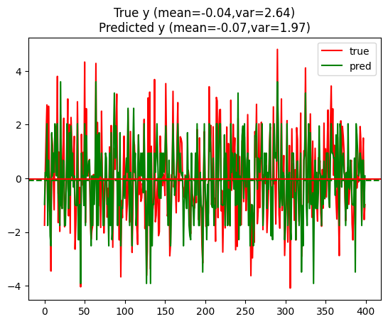

```python
def plot_verus(s):
    y = test_Y[s]
    y_mean = y.mean()
    y_var = ((y - y_mean)**2).mean()

    y_pred = model.predict(test_X[s])
    y_pred_mean = y_pred.mean()
    y_pred_var = ((y_pred - y_pred_mean)**2).mean()

    plt.plot(y, 'red', label='true')
    plt.plot(y_pred, 'green', label='pred')
    plt.legend()
    plt.title('True y (mean={:.2f},var={:.2f})\nPredicted y (mean={:.2f},var={:.2f})'.format(y_mean, y_var, y_pred_mean,y_pred_var))
    plt.axhline(y=y_mean, color='r', linestyle='-')
    plt.axhline(y=y_pred_mean, color='g', linestyle='--')


s = 1
plot_verus(s)
```

In regression problems, we aim to come up with a model that yields the best predictive performance (on new data). Empirically, an estimate of the expected error is the mean squared error (MSE), defined as the average squared distance between prediction $\hat{Y}_i$ and true value $Y_i$ for observations in the test set. In Machine learning papers, people typically report the square root of MSE to evaluate and compare the performances of different regression models. This metric is known as RMSE.